# PCBP1 workflow

Data: “Iron-sensitive RNA regulation by poly C binding proteins” (PMID 41036621), two GEO series of K562 short-read RNA-seq (polyA, paired-end 150), three biological replicates per condition, quantified with Salmon (v1.10.2) against GENCODE v43:

- GSE279951 [P1KD]: shRNA against luciferase (`shCtrl`) or PCBP1 (`shPCBP1`).
- GSE279949 [chelator]: DMSO (control) or iron chelator 21H7 (`CHEL`), overnight.

The two DTU comparisons at a glance. In each contrast the first term is the test group and the subtracted one the reference; the test group is the condition with more PCBP1 activity, so it is the up side for splicelogic.

|  | PCBP1 knockdown (GSE279951) | Iron chelation (GSE279949) |
| --- | --- | --- |
| Contrast | `WT_vs_KD = conditionWT - conditionKD` | `CHEL_vs_DMSO = conditionCHEL - conditionDMSO` |
| Test group (up) | `WT` (shCtrl) | `CHEL` (21H7) |
| Reference (down) | `KD` (shPCBP1) | `DMSO` |
| Positive estimate | transcript used more in WT | transcript used more after chelation |
| IE event | exon in WT transcripts, lost after KD | exon in chelated transcripts, absent from DMSO ones |
| FDR filter | `regular_FDR < 0.1` | `regular_FDR < 0.1` |

```r
library(splicelogic)
library(SummarizedExperiment)
library(GenomicFeatures)
library(dplyr)
library(ggplot2)
library(satuRn)
library(limma)
library(tibble)
library(tximeta)
library(here)
# splicelogic devel, loaded from source: clone the repo next to this one
#   git clone -b devel https://github.com/thelovelab/splicelogic.git ../splicelogic
# then load it with devtools (install.packages("devtools") if needed)
devtools::load_all(here("../splicelogic"))
```

# Data

Shared by both comparisons: the downloads, the `SummarizedExperiment` with all 12 samples, and the GENCODE v43 TxDb and exons the DTU results are mapped onto.

## Download data

GEO bundles one Salmon `quant.sf` per sample into a `RAW.tar` per series (~21MB each). They are extracted into `workflows/data/PCBP1/<GSE>/`.

GEO has only the `quant.sf` files, but tximeta also needs the Salmon `aux_info/meta_info.json` (it identifies the transcriptome from the index hash stored there). The authors’ `meta_info.json` is not on GEO: place it at `workflows/data/PCBP1/meta_info.json` and it is copied into an `aux_info/` folder next to the quant files of each series (same Salmon index for both).

```r
options(timeout = 600)
geo_dir <- here("workflows/data/PCBP1")
for (gse in c("GSE279949", "GSE279951")) {
  dest <- file.path(geo_dir, gse)
  dir.create(dest, recursive = TRUE, showWarnings = FALSE)
  tar_file <- file.path(dest, paste0(gse, "_RAW.tar"))
  download.file(
    paste0("https://ftp.ncbi.nlm.nih.gov/geo/series/GSE279nnn/", gse,
           "/suppl/", gse, "_RAW.tar"),
    tar_file, mode = "wb"
  )
  untar(tar_file, exdir = dest)
  file.remove(tar_file)
  dir.create(file.path(dest, "aux_info"), showWarnings = FALSE)
  file.copy(file.path(geo_dir, "meta_info.json"), file.path(dest, "aux_info"))
}
list.files(geo_dir, recursive = TRUE)
```

```r
library(txdbmaker)
# load TxDb for GRanges conversion
# the quant.sf files use GENCODE v43 transcript IDs (with version), so build the
# TxDb from the same release: the v48 TxDb would drop transcripts whose version changed
# download once (warning: ~50MB compressed, slow from EBI)
gtf <- here("workflows/data/gencode.v43.annotation.gtf.gz")
# curl with -C - resumes a partial file (EBI often times out mid-transfer);
# --retry re-attempts on failure instead of restarting from zero
system2("curl", c("-C", "-", "-L", "--retry", "5", "--retry-delay", "5",
                  "-o", shQuote(gtf),
                  "https://ftp.ebi.ac.uk/pub/databases/gencode/Gencode_human/release_43/gencode.v43.annotation.gtf.gz"))

txdb <- txdbmaker::makeTxDbFromGFF(gtf, format = "gtf")
# GENCODE v43 has ~252k transcripts; far fewer means the GTF download was cut short
length(AnnotationDbi::keys(txdb, "TXNAME"))
# save to not rebuild every time
AnnotationDbi::saveDb(txdb, here("workflows/data/gencode.v43.sqlite"))
```

## Build the SummarizedExperiment

One `SummarizedExperiment` with the 12 samples of both series, imported with tximeta. The sample table is parsed from the file names, `<GSM>_<group>_<replicate>_quant.sf.txt.gz`.

```r
txdb <- AnnotationDbi::loadDb(here("workflows/data/gencode.v43.sqlite"))
tx2gene <- AnnotationDbi::select(txdb, keys(txdb, "TXNAME"), "GENEID", "TXNAME")

coldata <- data.frame(
  files = list.files(here("workflows/data/PCBP1"),
                     pattern = "_quant\\.sf\\.txt\\.gz$",
                     recursive = TRUE, full.names = TRUE)
) |>
  dplyr::mutate(
    series = basename(dirname(files)),
    geo_accession = sub("_.*", "", basename(files)),
    group = sub("^GSM[0-9]+_(.+)_[0-9]+_quant.*", "\\1", basename(files)),
    replicate = sub(".*_([0-9]+)_quant.*", "\\1", basename(files)),
    names = paste(group, replicate, sep = "_"),
    experiment = dplyr::case_when(
      series == "GSE279951" ~ "PCBP1_KD",
      series == "GSE279949" ~ "chelator"
    ),
    condition = dplyr::case_when(
      group == "shCtrl" ~ "WT",
      group == "shPCBP1" ~ "KD",
      group == "DMSO" ~ "DMSO",
      group == "CHEL" ~ "CHEL"
    )
  )
coldata

# check how many transcripts in the quant files are in txdb (should be 1;
# tximeta below fails if any are missing)
read.delim(coldata$files[1])$Name %in% tx2gene$TXNAME |> mean()

# tximeta matches the index hash in aux_info/meta_info.json to GENCODE v43, then
# looks in its BiocFileCache for a TxDb named after the v43 GTF: register the
# TxDb built above under that name, so tximeta loads it instead of downloading
# and building its own
bfc <- BiocFileCache::BiocFileCache(tximeta:::getBFCLoc(), ask = FALSE)
in_cache <- BiocFileCache::bfcquery(
  bfc, "gencode.v43.annotation.gtf.gz", field = "rname", exact = TRUE
)
if (nrow(in_cache) == 0) {
  BiocFileCache::bfcadd(
    bfc, rname = "gencode.v43.annotation.gtf.gz",
    fpath = here("workflows/data/gencode.v43.sqlite"), action = "asis"
  )
}

# transcript-level counts; dtuScaledTPM scales TPM by the median transcript
# length of each gene, the tximport setting recommended for DTU
se <- tximeta::tximeta(
  coldata, countsFromAbundance = "dtuScaledTPM", tx2gene = tx2gene
)

se

saveRDS(se, here("workflows/data/PCBP1/PCBP1_SummarizedExperiment.rds"))
```

```r
se <- readRDS(here("workflows/data/PCBP1/PCBP1_SummarizedExperiment.rds"))
dim(se)
```

```
## [1] 252045     12
```

```r
colData(se)
```

```
## DataFrame with 12 rows and 7 columns
##                series geo_accession       group   replicate       names
##           <character>   <character> <character> <character> <character>
## DMSO_1      GSE279949    GSM8583999        DMSO           1      DMSO_1
## DMSO_2      GSE279949    GSM8584000        DMSO           2      DMSO_2
## DMSO_3      GSE279949    GSM8584001        DMSO           3      DMSO_3
## CHEL_1      GSE279949    GSM8584002        CHEL           1      CHEL_1
## CHEL_2      GSE279949    GSM8584003        CHEL           2      CHEL_2
## ...               ...           ...         ...         ...         ...
## shCtrl_2    GSE279951    GSM8584115      shCtrl           2    shCtrl_2
## shCtrl_3    GSE279951    GSM8584116      shCtrl           3    shCtrl_3
## shPCBP1_1   GSE279951    GSM8584117     shPCBP1           1   shPCBP1_1
## shPCBP1_2   GSE279951    GSM8584118     shPCBP1           2   shPCBP1_2
## shPCBP1_3   GSE279951    GSM8584119     shPCBP1           3   shPCBP1_3
##            experiment   condition
##           <character> <character>
## DMSO_1       chelator        DMSO
## DMSO_2       chelator        DMSO
## DMSO_3       chelator        DMSO
## CHEL_1       chelator        CHEL
## CHEL_2       chelator        CHEL
## ...               ...         ...
## shCtrl_2     PCBP1_KD          WT
## shCtrl_3     PCBP1_KD          WT
## shPCBP1_1    PCBP1_KD          KD
## shPCBP1_2    PCBP1_KD          KD
## shPCBP1_3    PCBP1_KD          KD
```

## Exons for splicelogic

```r
# build exon GRangesList and rename from internal TXID to TXNAME
txdb <- AnnotationDbi::loadDb(here("workflows/data/gencode.v43.sqlite"))
exons <- exonsBy(txdb, by = "tx")
txps <- AnnotationDbi::select(txdb, keys(txdb, "TXID"), c("TXNAME", "GENEID"), "TXID") |>
  tibble::as_tibble() |>
  dplyr::mutate(TXID = as.character(TXID))
# rename exons to match tx_name in se, matching by TXID
all.equal(names(exons), txps$TXID)
names(exons) <- txps$TXNAME[match(names(exons), txps$TXID)]
saveRDS(exons, here("workflows/data/PCBP1/gencode.v43.exons.rds"))
```

```r
# load from saved sqlite
txdb <- AnnotationDbi::loadDb(here("workflows/data/gencode.v43.sqlite"))
# load exons from saved rds
exons <- readRDS(here("workflows/data/PCBP1/gencode.v43.exons.rds"))
```

# PCBP1 knockdown (GSE279951)

## DTU testing with satuRn: PCBP1 knockdown (GSE279951)

We compare control shRNA (`WT`) against PCBP1 knockdown (`KD`) using satuRn. GEO gives no pairing between the replicates of the two conditions, so there is no blocking term (unlike `donor` in the RBP workflow).

```r
se_kd <- se[, se$experiment == "PCBP1_KD"]
dim(se_kd)
```

```
## [1] 252045      6
```

```r
# counts >= 10 in at least 3 samples (the size of one group)
keep <- rowSums(assay(se_kd) >= 10) >= 3
se_kd <- se_kd[keep, ]
dim(se_kd)
```

```
## [1] 94008     6
```

```r
# KD as reference level
colData(se_kd)$condition <- factor(colData(se_kd)$condition, levels = c("KD", "WT"))

# build design from the factor directly (matches satuRn vignette convention)
condition <- colData(se_kd)$condition
design <- model.matrix(~ 0 + condition)

L <- limma::makeContrasts(
  WT_vs_KD = conditionWT - conditionKD,
  levels = design
)
L
```

```
##              Contrasts
## Levels        WT_vs_KD
##   conditionKD       -1
##   conditionWT        1
```

```r
rowData(se_kd)$isoform_id <- rowData(se_kd)$tx_name
# flatten CharacterList gene_id to plain character
rowData(se_kd)$gene_id <- vapply(rowData(se_kd)$gene_id, `[`, character(1), 1)

se_kd <- se_kd[
  duplicated(rowData(se_kd)$gene_id) |
    duplicated(rowData(se_kd)$gene_id, fromLast = TRUE),
]
dim(se_kd)
```

```
## [1] 84374     6
```

```r
se_kd <- satuRn::fitDTU(se_kd, formula = ~0 + condition)
```

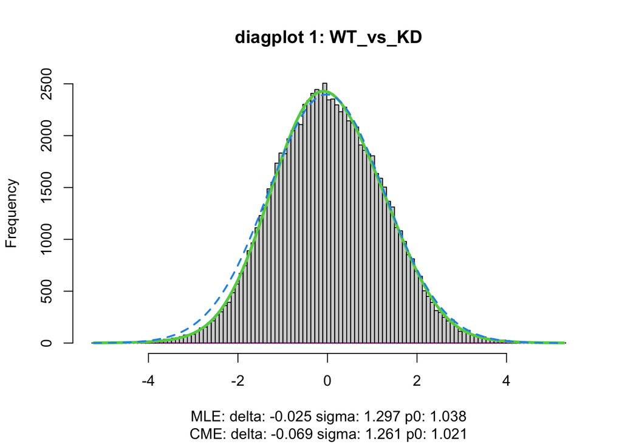

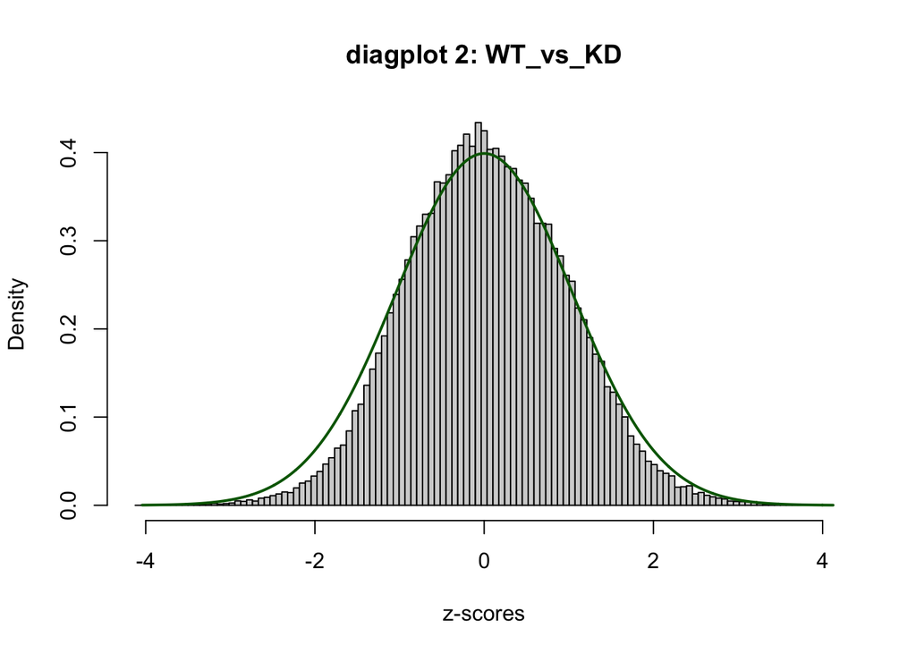

```r
se_kd <- satuRn::testDTU(
  object = se_kd,
  contrasts = L,
  diagplot1 = TRUE,
  diagplot2 = TRUE
)
```

```r
gene_ids <- rowData(se_kd)$gene_id

# every tested transcript; `sig_res_kd` below is the significant subset, and the
# non-significant rows are the background pool for slSampleNonEventExons()
dtu_res_kd <- rowData(se_kd)[["fitDTUResult_WT_vs_KD"]] |>
  as.data.frame() |>
  tibble::rownames_to_column("tx_name") |>
  tibble::as_tibble() |>
  dplyr::mutate(gene_id = gene_ids) |>
  dplyr::select(tx_name, gene_id, estimates, pval, regular_FDR) |>
  dplyr::arrange(pval)

sig_res_kd <- dtu_res_kd |> dplyr::filter(regular_FDR < 0.1)

sig_res_kd <- sig_res_kd |> mutate(tx_id = tx_name)
sig_res_kd
```

```
## # A tibble: 616 × 6
##    tx_name           gene_id            estimates        pval regular_FDR tx_id
##    <chr>             <chr>                  <dbl>       <dbl>       <dbl> <chr>
##  1 ENST00000647557.2 ENSG00000104824.18    -1.78  0.000000102     0.00395 ENST0…
##  2 ENST00000458500.5 ENSG00000147403.18    -0.437 0.000000127     0.00395 ENST0…
##  3 ENST00000440232.7 ENSG00000062822.16     0.910 0.000000140     0.00395 ENST0…
##  4 ENST00000592590.6 ENSG00000182087.14    -1.31  0.000000285     0.00596 ENST0…
##  5 ENST00000468686.5 ENSG00000161179.14    -0.662 0.000000367     0.00596 ENST0…
##  6 ENST00000321153.9 ENSG00000177600.9      0.556 0.000000424     0.00596 ENST0…
##  7 ENST00000334478.9 ENSG00000123349.15     0.930 0.000000580     0.00685 ENST0…
##  8 ENST00000677814.1 ENSG00000082898.19     0.635 0.000000649     0.00685 ENST0…
##  9 ENST00000532004.5 ENSG00000177600.9     -0.590 0.000000811     0.00761 ENST0…
## 10 ENST00000371579.7 ENSG00000176978.15     0.946 0.00000146      0.0123  ENST0…
## # ℹ 606 more rows
```

```r
# save for later use
saveRDS(dtu_res_kd, here("workflows/data/PCBP1/dtu_res_kd.rds"))
saveRDS(sig_res_kd, here("workflows/data/PCBP1/sig_res_kd.rds"))
```

```r
# load the saved DTU results
sig_res_kd <- readRDS(here("workflows/data/PCBP1/sig_res_kd.rds"))
sig_res_kd
```

```
## # A tibble: 616 × 6
##    tx_name           gene_id            estimates        pval regular_FDR tx_id
##    <chr>             <chr>                  <dbl>       <dbl>       <dbl> <chr>
##  1 ENST00000647557.2 ENSG00000104824.18    -1.78  0.000000102     0.00395 ENST0…
##  2 ENST00000458500.5 ENSG00000147403.18    -0.437 0.000000127     0.00395 ENST0…
##  3 ENST00000440232.7 ENSG00000062822.16     0.910 0.000000140     0.00395 ENST0…
##  4 ENST00000592590.6 ENSG00000182087.14    -1.31  0.000000285     0.00596 ENST0…
##  5 ENST00000468686.5 ENSG00000161179.14    -0.662 0.000000367     0.00596 ENST0…
##  6 ENST00000321153.9 ENSG00000177600.9      0.556 0.000000424     0.00596 ENST0…
##  7 ENST00000334478.9 ENSG00000123349.15     0.930 0.000000580     0.00685 ENST0…
##  8 ENST00000677814.1 ENSG00000082898.19     0.635 0.000000649     0.00685 ENST0…
##  9 ENST00000532004.5 ENSG00000177600.9     -0.590 0.000000811     0.00761 ENST0…
## 10 ENST00000371579.7 ENSG00000176978.15     0.946 0.00000146      0.0123  ENST0…
## # ℹ 606 more rows
```

## Splice event detection with splicelogic for PCBP1 knockdown

We run event detection on the PCBP1 knockdown comparison (`sig_res_kd`); the chelator comparison gets the same steps in its own section below.

### Direction of the events

WT (PCBP1 present) is the up side and KD (no PCBP1) the reference. In the contrast `WT_vs_KD = conditionWT - conditionKD`, WT is the test group and KD the reference (the subtracted term), so the estimate is WT minus KD: positive when a transcript is used more in WT, negative when it is used more in KD. This reverses the usual way of describing a knockdown (“KD vs control”), so that the up side is the condition with PCBP1 present. splicelogic treats the down (negative-estimate) transcripts as the reference, so every event describes what WT transcripts do compared with KD ones, as in the RBP workflow. With `~ 0 + condition` there is no intercept, so the level order (`levels = c("KD", "WT")`) does not change the fit: the contrast alone sets the direction.

| Event | What happens | What it suggests about PCBP1 |
| --- | --- | --- |
| IE | Exon is in WT transcripts and lost after KD | PCBP1 promotes inclusion |

PCBP1 binding upstream of an exon typically promotes its inclusion, and knockdown lowers it, so that pattern shows up as IE events, which the analyses below focus on.

```r
# prepare exons for splicelogic
sig_exons <- prepare_exons(
  txdb, sig_res_kd, coef_col = "estimates", verbose = TRUE
)
```

```
## Extracting exons from TxDb...
```

```
## Mapping transcript IDs...
```

```
## Merging DTU results onto exons...
```

```
## Done. Returned 6792 exon ranges from 616 unique transcripts.
```

```r
#find ie
ie_events <- sig_exons |> preprocess(coef_col = "estimates") |> find_ie()

#find all events
events <- sig_exons |> preprocess(coef_col = "estimates")|> find_all_events()
```

```
## Calculating skipped exon events...
```

```
## Calculating included exon events...
```

```
## Calculating mutually exclusive exon events...
```

```
## Calculating retained intron events...
```

```
## Calculating spliced intron events...
```

```
## Calculating alternative 5' splice site events...
```

```
## Calculating alternative 3' splice site events...
```

```
## Calculating alternative transcription start site events...
```

```
## Calculating alternative transcription end site events...
```

```
## Done! 480 events detected.
```

```r
# define a helper function
my_paste <- \(x) paste(unique(x), collapse = ",")
# rows are collapsed when they share the same exon and the same event type. The
# exon is identified by `exon_key` (gene, chromosome, start, end and strand),
# built as in the vignette's recipe for an exon id, rather than by `exon_id`:
# the annotation gives the same exon more than one id when it is coding in one
# transcript and non-coding in another
collapsed_events <- events |>
    dplyr::mutate(exon_key = paste(gene_id, seqnames, start, end, strand, sep = ":")) |>
    dplyr::group_by(exon_key, event_type) |>
    plyranges::reduce_ranges_directed(
        n = plyranges::n(),
        exon_id = my_paste(exon_id),
        tx_id = my_paste(tx_id),
        exon_rank = my_paste(exon_rank),
        event_tx_id = my_paste(event_tx_id),
  )
```

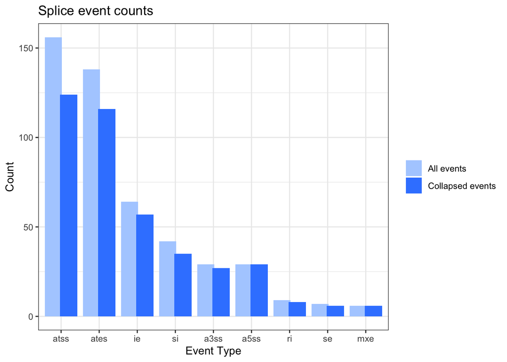

```r
event_counts <- events |>
    as_tibble() |>
    dplyr::group_by(event_type) |>
    dplyr::summarise(count = dplyr::n())

collapsed_event_counts <- collapsed_events |>
    as_tibble() |>
    dplyr::group_by(event_type) |>
    dplyr::summarise(count = dplyr::n())

# combine both count tables into one, labelled by source
counts <- dplyr::bind_rows(
  "All events" = event_counts,
  "Collapsed events" = collapsed_event_counts,
  .id = "set"
)

# event types from most to fewest events
counts$event_type <- factor(
  counts$event_type,
  levels = event_counts$event_type[order(-event_counts$count)]
)

ggplot(counts, aes(x = event_type, y = count, fill = set)) +
  geom_col(position = position_dodge(width = 0.8)) +
  scale_fill_manual(values = c(
    "All events" = "#B0CFFF",       # light blue
    "Collapsed events" = "#3A86FF"  # darker blue
  )) +
  labs(title = "Splice event counts",
  x = "Event Type", y = "Count", fill = NULL) +
  theme_bw()
```

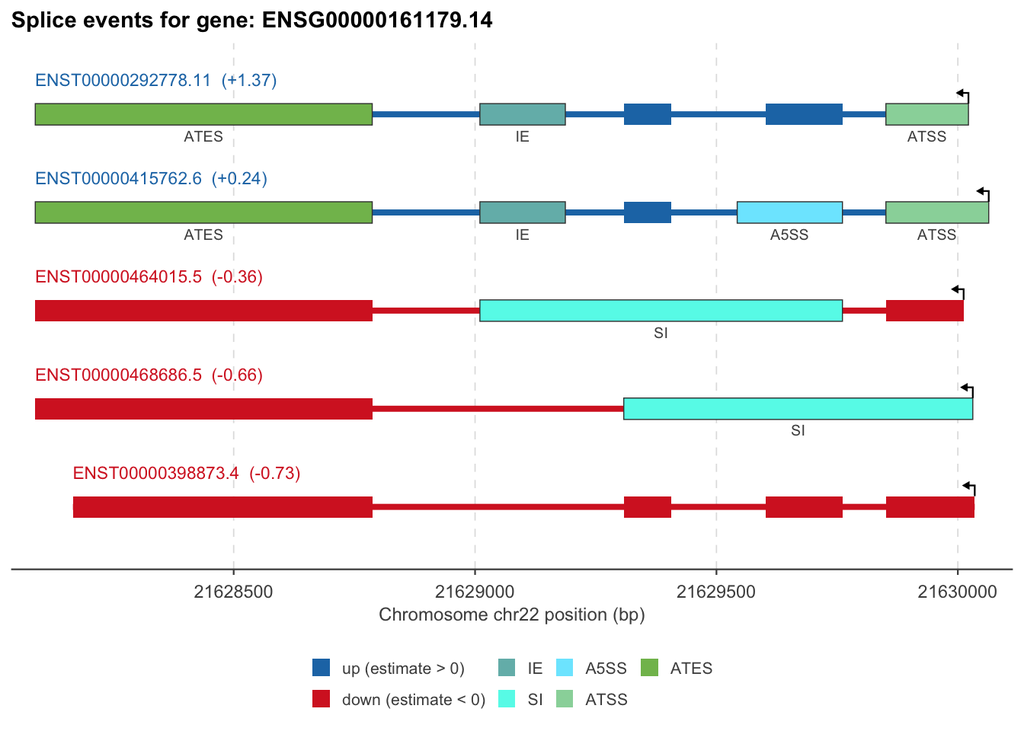

```r
# use splicelogic's built-in plotting function to visualize events for a specific gene:
# the one with the most IE events
gene_of_interest <- names(sort(table(ie_events$gene_id), decreasing = TRUE))[1]
# filter events for the gene of interest
events_for_gene <- events[events$gene_id == gene_of_interest]

# visualize the events for the gene of interest
splicelogic::plot_transcripts(events_for_gene, sig_exons, rescale_introns = FALSE) +
  ggtitle(paste("Splice events for gene:", gene_of_interest))
```

```r
# make a plot for each gene with events and save to files
# plot_transcripts_by_gene returns a list of ggplot objects, one for each gene
plots <- plot_transcripts_by_gene(events, sig_exons)
# save each plot to the same pdf file
pdf(here("workflows/figures/PCBP1_splice_events_by_gene.pdf"), width = 8, height = 6)
for (gene in names(plots)) {
    print(plots[[gene]])
}
dev.off()
```

## Collapse redundant events

`find_ie()` returns an exon once per transcript pair it is part of: an exon in two up transcripts and skipped by two down ones comes back four times. The event counts above already collapse these (`collapsed_events`). For the sequence analyses below we also keep one row per exon, so that an exon shared by many transcripts does not weigh more in the profiles and logos, and the background set is sized by exons rather than pairs. `n` records how many pairs each exon came from. The collapse is the same as in `collapse_redundant_events`, applied to the IE events, and like it collapses rows only for the same exon (gene, chromosome, start, end, strand) and the same event type. Set `collapse_exons <- FALSE` to run the sequence analyses on every event instead, as before the collapse; the collapsed set stays available as `ie_collapsed`.

```r
# TRUE: the sequence analyses below use one row per exon. FALSE: they use every
# IE event, one row per transcript pair, as before the collapse, to
# compare
collapse_exons <- TRUE

ie_collapsed <- ie_events |>
    dplyr::mutate(exon_key = paste(gene_id, seqnames, start, end, strand, sep = ":")) |>
    dplyr::group_by(exon_key, event_type) |>
    plyranges::reduce_ranges_directed(
        n = plyranges::n(),
        gene_id = my_paste(gene_id),
        exon_id = my_paste(exon_id),
        tx_id = my_paste(tx_id),
        exon_rank = my_paste(exon_rank),
        event_tx_id = my_paste(event_tx_id),
  )

data.frame(
  events = length(ie_events),
  exons  = length(ie_collapsed),
  max_n  = max(ie_collapsed$n)
)
```

```
##   events exons max_n
## 1     64    57     4
```

```r
# the set the sequence analyses below use
ie_exons <- if (collapse_exons) ie_collapsed else ie_events
```

### IE exons per gene

How the IE events spread across genes: the number of distinct IE exons in each gene. `ie_collapsed` already has one row per exon and gene, with `n` the events it came from, so the counts come straight from it.

```r
ie_per_gene <- ie_collapsed |>
  dplyr::group_by(gene_id) |>
  dplyr::summarise(n_events = sum(n),
                   n_exons  = plyranges::n())

data.frame(
  ie_events = length(ie_events),
  ie_exons  = length(ie_collapsed),
  ie_genes  = nrow(ie_per_gene)
)
```

```
##   ie_events ie_exons ie_genes
## 1        64       57       50
```

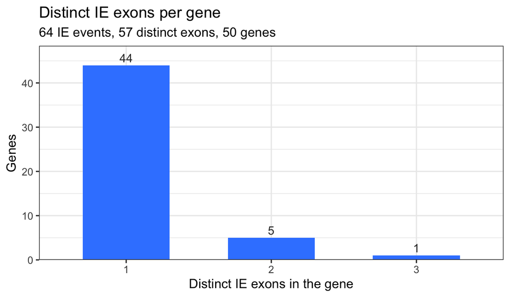

```r
# ggplot needs a data.frame, so the small per-gene summary is converted here
as.data.frame(ie_per_gene) |>
  dplyr::count(n_exons) |>
  ggplot(aes(x = factor(n_exons), y = n)) +
  geom_col(fill = "#3A86FF", width = 0.6) +
  geom_text(aes(label = n), vjust = -0.4, size = 3.5, colour = "grey20") +
  scale_y_continuous(expand = expansion(mult = c(0, 0.1))) +
  labs(title = "Distinct IE exons per gene",
       subtitle = sprintf("%d IE events, %d distinct exons, %d genes",
                          length(ie_events), length(ie_collapsed),
                          nrow(ie_per_gene)),
       x = "Distinct IE exons in the gene", y = "Genes") +
  theme_bw()
```

## Sequence context around the event exons, focusing on included exons (IE)

IE exons are the set analysed here (see *Direction of the events* above).

The analysis below uses a set of sequence-context helpers consolidated in `helper.R` (nucleotide-composition profiles, background exon sampling, splice-site logos and RBP motif scanning). The splicelogic package itself only exports `get_seq()` for sequence work, so these stay as paper-repo helpers (for now).

```r
source(here("workflows/helper.R"))
```

`slEventFlankProfiles()` takes a finder’s output straight away: it flanks each exon (strand-aware, so “upstream” is 5’ in transcription order), slides overlapping windows across the flank, and returns the per-window nucleotide fractions for each side.

```r
ie_profiles <- slEventFlankProfiles(ie_exons, genome = "hg38", width = 100)

# rows = exons, cols = window_nucleotide (e.g. w1_A)
dim(ie_profiles$upstream)
```

```
## [1] 57 76
```

```r
dim(ie_profiles$downstream)
```

```
## [1] 57 76
```

### Background set

We want to compare the sequence context of the events with that of a control set. For the control set (non-event exons), we sample as many exons as there are in `ie_exons` (one per IE exon, or one per IE event with `collapse_exons = FALSE`), drawn at random from the internal exons of transcripts with no evidence of differential usage (`pval > 0.5`).

```r
dtu_res_kd <- readRDS(here("workflows/data/PCBP1/dtu_res_kd.rds"))
non_event <- slSampleNonEventExons(
  dtu_res_kd, exons, n = ie_exons, pval_min = 0.5, seed = 1
)
non_event
```

```
## GRanges object with 57 ranges and 5 metadata columns:
##        seqnames              ranges strand |   exon_id         exon_name
##           <Rle>           <IRanges>  <Rle> | <integer>       <character>
##    [1]     chr9   41132228-41132357      - |    377620 ENSE00003706236.1
##    [2]     chr2   11626962-11627104      + |     75599 ENSE00000711297.1
##    [3]    chr11   46630897-46630991      + |    424501 ENSE00002726668.1
##    [4]     chr1     8465925-8466023      - |     41093 ENSE00002965848.1
##    [5]    chr19   10996494-10996544      + |    684592 ENSE00003667937.1
##    ...      ...                 ...    ... .       ...               ...
##   [53]     chr4     1349524-1349854      + |    184305 ENSE00001683285.1
##   [54]     chr1   42750186-42750336      - |     48456 ENSE00003662107.1
##   [55]    chr17     7925683-7925726      - |    644247 ENSE00003463535.1
##   [56]     chr6   85572137-85572215      - |    281084 ENSE00003635923.1
##   [57]     chr3 136343832-136344006      - |    176360 ENSE00003654340.1
##        exon_rank             tx_id      pval
##        <integer>       <character> <numeric>
##    [1]        14 ENST00000610358.4  0.509966
##    [2]         8 ENST00000396123.2  0.516300
##    [3]         3 ENST00000578626.5  0.520284
##    [4]        12 ENST00000337907.7  0.520845
##    [5]        11 ENST00000643549.1  0.523675
##    ...       ...               ...       ...
##   [53]         3 ENST00000677428.1  0.959390
##   [54]        11 ENST00000495874.5  0.971089
##   [55]         2 ENST00000576981.1  0.985176
##   [56]         4 ENST00000682034.1  0.988447
##   [57]        29 ENST00000434713.6  0.997715
##   -------
##   seqinfo: 25 sequences (1 circular) from an unspecified genome; no seqlengths
```

```r
non_event_profiles <- slEventFlankProfiles(
  non_event, genome = "hg38", width = 100
)
dim(non_event_profiles$upstream)
```

```
## [1] 57 76
```

The IE profiles stacked over the non-IE ones, on the same axes:

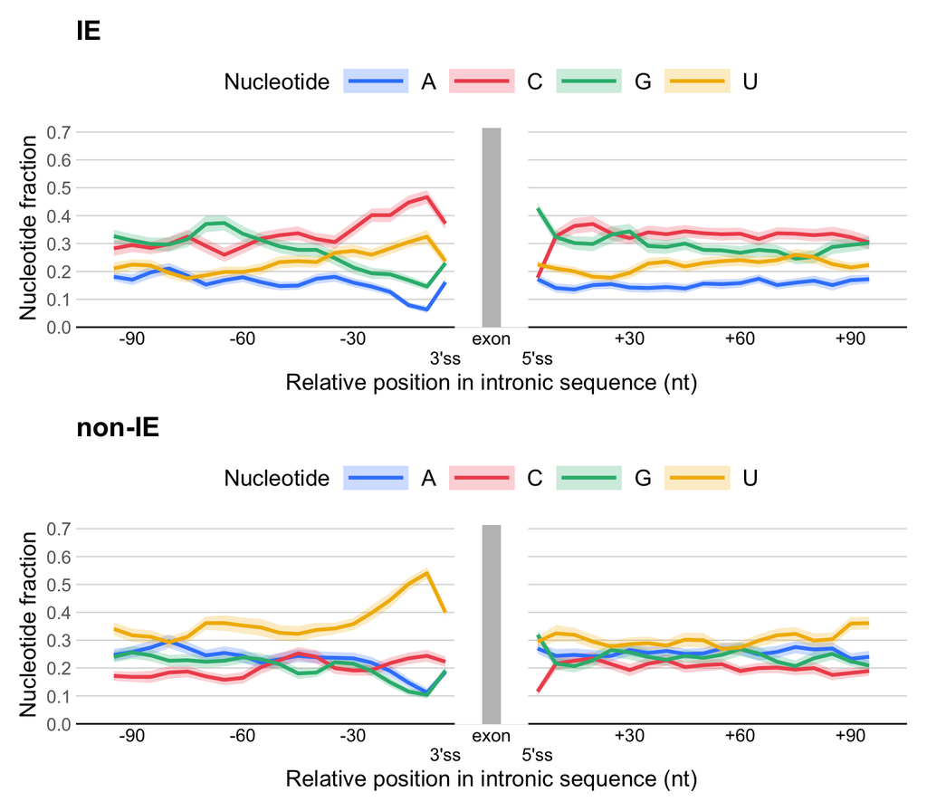

```r
patchwork::wrap_plots(
  slPlotFlankProfiles(ie_profiles, exon_label = "IE"),
  slPlotFlankProfiles(non_event_profiles, exon_label = "non-IE"),
  ncol = 1
)
```

The IE and non-IE sets, one panel per nucleotide (mean ± standard error), and next to them the difference between them, IE minus non-IE:

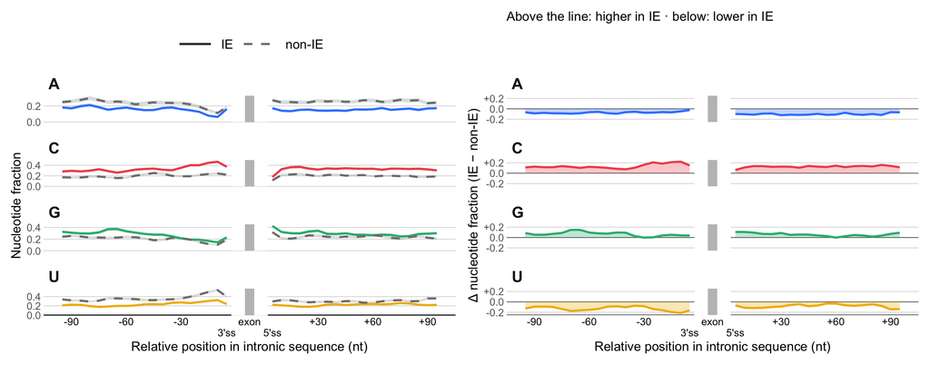

```r
ie_vs_non_event <- list(IE = ie_profiles, "non-IE" = non_event_profiles)

patchwork::wrap_plots(
  slPlotFlankProfilesByNt(ie_vs_non_event),
  slPlotFlankProfilesByNt(ie_vs_non_event, difference = TRUE),
  nrow = 1
)
```

An alternative, within-transcript control: for each event, the internal exon of the same transcript that is shared with the event partner and closest in rank to the event exon.

```r
matched <- slMatchedNonEventExons(ie_events, exons)

slEventFlankProfiles(matched, genome = "hg38", width = 100) |>
  slPlotFlankProfiles(exon_label = "matched exon")
```

[output not shown]

## Splice-site sequence logos

The window profiles above average over 10 bp, which smooths the splice site away. `slFlankLogoMatrices()` keeps every base position separate and returns a position frequency matrix per side, running `width` bases into the intron and `exon_bases` into the exon so the boundary is inside the matrix.

Note which site each side carries: the region **upstream** of an exon is the end of the preceding intron and holds the **3’ splice site** (acceptor, `...ag | EXON`); the region **downstream** is the start of the following intron and holds the **5’ splice site** (donor, `EXON | gu...`).

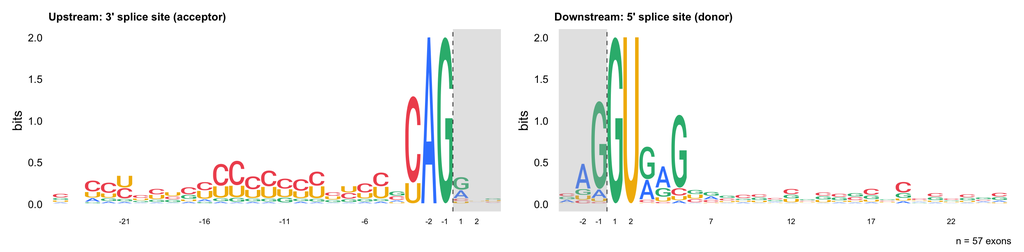

```r
ie_logo <- slFlankLogoMatrices(ie_exons, genome = "hg38",
                               width = 25, exon_bases = 3)

# letter height = information content, the classic logo scaling: unconstrained
# positions shrink to nothing and the consensus stands out
slPlotFlankLogo(ie_logo, method = "bits")
```

The same for the background set, to see whether the event splice sites differ from those of exons in transcripts with no differential usage.

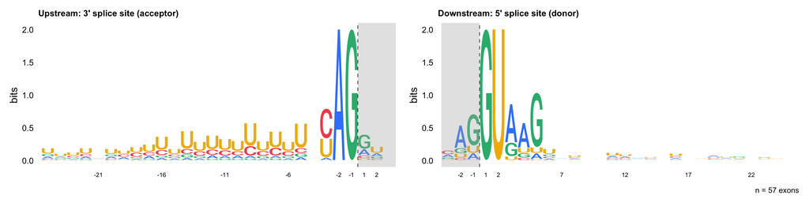

```r
non_event_logo <- slFlankLogoMatrices(non_event, genome = "hg38",
                                      width = 25, exon_bases = 3)

slPlotFlankLogo(non_event_logo, method = "bits")
```

```r
# where the two sets differ most, per position and nucleotide; upstream holds
# the 3' splice site, where a C-rich tract preceding the exon would sit
delta_up <- ie_logo$upstream - non_event_logo$upstream
round(delta_up[, order(-apply(abs(delta_up), 2, max))[1:6]], 3)
```

```
##      -14    -17    -15     -5    -22    -25
## A -0.053 -0.070 -0.105 -0.018 -0.088 -0.053
## C  0.404  0.228  0.351  0.316  0.298  0.298
## G -0.018  0.193 -0.070 -0.018  0.035  0.035
## U -0.333 -0.351 -0.175 -0.281 -0.246 -0.281
```

```r
delta_down <- ie_logo$downstream - non_event_logo$downstream
round(delta_down[, order(-apply(abs(delta_down), 2, max))[1:6]], 3)
```

```
##        3     11     19     12     16     21
## A -0.333 -0.053 -0.193 -0.228 -0.088 -0.140
## C  0.053  0.175  0.246  0.193  0.088  0.228
## G  0.333  0.140  0.123  0.140  0.228  0.000
## U -0.053 -0.263 -0.175 -0.105 -0.228 -0.088
```

## Genes with IE events

Which genes carry the IE exons, how many of them are core essential genes, and a small GO enrichment. The GO background is every gene tested for DTU (`dtu_res_kd`): only multi-isoform genes expressed here could have produced an event, so the whole genome would be the wrong reference.

```r
library(org.Hs.eg.db)

# GENCODE ids carry a version suffix; org.Hs.eg.db keys do not
strip_version <- \(x) sub("\\.\\d+$", "", x)

ie_genes <- ie_events |>
  as_tibble() |>
  dplyr::group_by(gene_id) |>
  dplyr::summarise(n_events = dplyr::n(),
                   n_exons  = dplyr::n_distinct(exon_id)) |>
  dplyr::mutate(
    ensembl = strip_version(gene_id),
    symbol  = AnnotationDbi::mapIds(org.Hs.eg.db, ensembl,
                                    "SYMBOL", "ENSEMBL"),
    entrez  = AnnotationDbi::mapIds(org.Hs.eg.db, ensembl,
                                    "ENTREZID", "ENSEMBL")
  )

universe <- unique(strip_version(dtu_res_kd$gene_id))
```

Essential genes are taken from the core essential gene list CEGv2 (Hart et al. 2017, *G3*): 684 genes required for fitness across CRISPR screens in many cell lines.

```r
ceg_file <- here("workflows/data/CEGv2.txt")
if (!file.exists(ceg_file)) {
  download.file(
    "https://raw.githubusercontent.com/hart-lab/bagel/master/CEGv2.txt",
    ceg_file
  )
}
ceg <- read.delim(ceg_file, colClasses = "character")

ie_genes$essential <- ie_genes$entrez %in% ceg$ENTREZ_ID

data.frame(
  ie_events        = length(ie_events),
  ie_genes         = nrow(ie_genes),
  with_symbol      = sum(!is.na(ie_genes$symbol)),
  essential        = sum(ie_genes$essential),
  genes_tested_dtu = length(universe)
)
```

```
##   ie_events ie_genes with_symbol essential genes_tested_dtu
## 1        64       50          50         7            12435
```

```r
# the 20 IE genes with the most events (`ie_genes` has them all)
ie_genes |>
  dplyr::arrange(dplyr::desc(n_events), symbol) |>
  dplyr::select(symbol, gene_id, n_events, n_exons, essential) |>
  head(20)
```

```
## # A tibble: 20 × 5
##    symbol   gene_id            n_events n_exons essential
##    <chr>    <chr>                 <int>   <int> <lgl>
##  1 PCYT2    ENSG00000185813.11        4       3 FALSE
##  2 YDJC     ENSG00000161179.14        4       2 FALSE
##  3 RBM42    ENSG00000126254.12        3       2 FALSE
##  4 CENPX    ENSG00000169689.15        2       1 FALSE
##  5 FLNA     ENSG00000196924.19        2       2 FALSE
##  6 GUK1     ENSG00000143774.18        2       2 TRUE
##  7 GUSB     ENSG00000169919.17        2       2 FALSE
##  8 RPL10    ENSG00000147403.18        2       1 FALSE
##  9 TMC6     ENSG00000141524.19        2       2 FALSE
## 10 ACADVL   ENSG00000072778.20        1       1 FALSE
## 11 AMPD2    ENSG00000116337.20        1       1 FALSE
## 12 ANXA2    ENSG00000182718.18        1       1 FALSE
## 13 AP2M1    ENSG00000161203.14        1       1 FALSE
## 14 AP2S1    ENSG00000042753.12        1       1 FALSE
## 15 APEH     ENSG00000164062.13        1       1 FALSE
## 16 ARHGEF12 ENSG00000196914.9         1       1 FALSE
## 17 BEX4     ENSG00000102409.10        1       1 FALSE
## 18 CARS1    ENSG00000110619.18        1       1 FALSE
## 19 DNMT1    ENSG00000130816.17        1       1 TRUE
## 20 EMP3     ENSG00000142227.11        1       1 FALSE
```

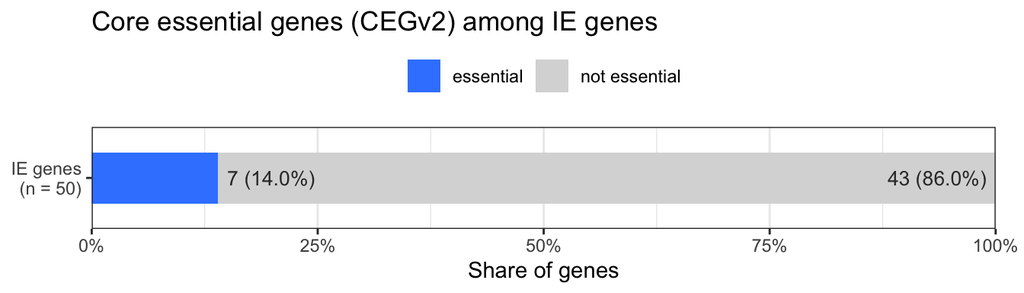

```r
# share of the IE genes that are core essential
ie_essential_df <- data.frame(
  set    = sprintf("IE genes\n(n = %s)", scales::comma(nrow(ie_genes))),
  status = factor(c("essential", "not essential"),
                  levels = c("essential", "not essential")),
  n      = c(sum(ie_genes$essential), sum(!ie_genes$essential))
) |>
  dplyr::mutate(frac  = n / sum(n),
                label = sprintf("%s (%.1f%%)", scales::comma(n), 100 * frac))

ggplot(ie_essential_df, aes(x = frac, y = set, fill = status)) +
  geom_col(position = position_stack(reverse = TRUE), width = 0.6) +
  geom_text(data = \(d) dplyr::filter(d, status == "essential"),
            aes(label = label), hjust = 0, nudge_x = 0.01,
            size = 3.5, colour = "grey20") +
  geom_text(data = \(d) dplyr::filter(d, status == "not essential"),
            aes(x = 0.99, label = label), hjust = 1,
            size = 3.5, colour = "grey20") +
  scale_fill_manual(values = c("essential"     = "#3A86FF",
                               "not essential" = "grey85")) +
  scale_x_continuous(labels = scales::percent, expand = c(0, 0)) +
  labs(title = "Core essential genes (CEGv2) among IE genes",
       x = "Share of genes", y = NULL, fill = NULL) +
  theme_bw() +
  theme(legend.position = "top",
        plot.margin = margin(5.5, 14, 5.5, 5.5))
```

```r
# GO biological process; cutoffs at 1 so the top terms are always shown, but
# with ~50 genes few will pass p.adjust < 0.05, so read p.adjust first
ie_go <- clusterProfiler::enrichGO(
  gene     = ie_genes$ensembl,
  universe = universe,
  OrgDb    = org.Hs.eg.db,
  keyType  = "ENSEMBL",
  ont      = "BP",
  pvalueCutoff = 1,
  qvalueCutoff = 1,
  readable = TRUE
)
as_tibble(ie_go) |>
  dplyr::select(Description, GeneRatio, BgRatio, pvalue, p.adjust, geneID) |>
  head(10)
```

```
## # A tibble: 10 × 6
##    Description                         GeneRatio BgRatio  pvalue p.adjust geneID
##    <chr>                               <chr>     <chr>     <dbl>    <dbl> <chr>
##  1 positive regulation of receptor-me… 3/50      30/9914 4.45e-4    0.385 AP2M1…
##  2 receptor internalization            4/50      81/9914 7.16e-4    0.385 AP2S1…
##  3 blood coagulation                   4/50      105/99… 1.88e-3    0.385 SYK/V…
##  4 coagulation                         4/50      105/99… 1.88e-3    0.385 SYK/V…
##  5 regulation of receptor internaliza… 3/50      50/9914 2.00e-3    0.385 AP2M1…
##  6 hemostasis                          4/50      108/99… 2.09e-3    0.385 SYK/V…
##  7 tubulin deacetylation               2/50      15/9914 2.51e-3    0.385 BEX4/…
##  8 positive regulation of receptor in… 2/50      17/9914 3.23e-3    0.385 AP2M1…
##  9 neutrophil mediated immunity        2/50      17/9914 3.23e-3    0.385 STXBP…
## 10 wound healing                       5/50      210/99… 3.97e-3    0.385 SYK/V…
```

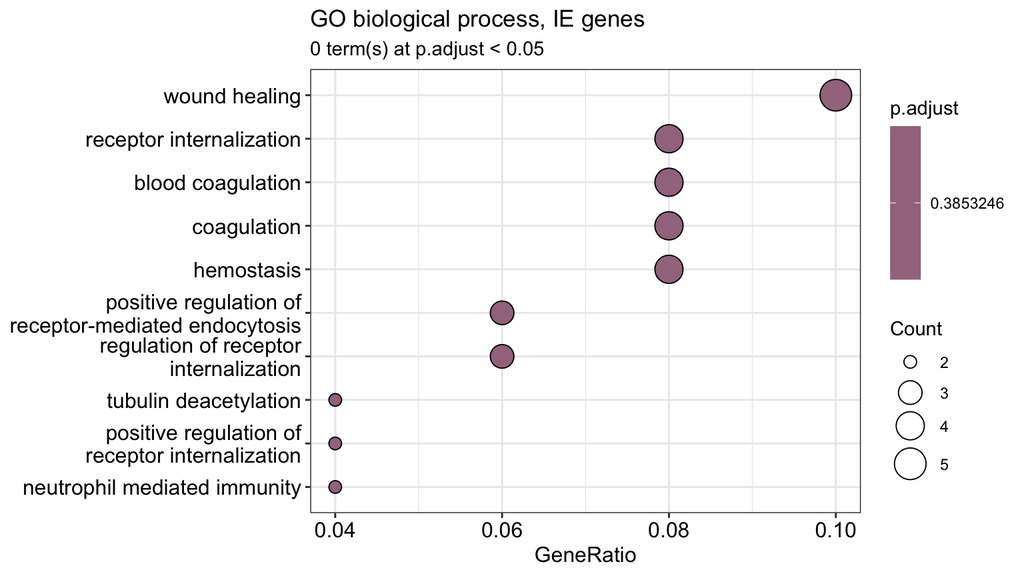

```r
enrichplot::dotplot(ie_go, showCategory = 10) +
  labs(title = "GO biological process, IE genes",
       subtitle = sprintf("%d term(s) at p.adjust < 0.05",
                          sum(ie_go@result$p.adjust < 0.05)))
```

# Iron chelation (GSE279949)

The same analysis for the iron chelation series. Objects from this comparison carry a `_chel` suffix, so they do not overwrite the knockdown ones above.

## DTU testing with satuRn: iron chelation (GSE279949)

Same steps, comparing the iron chelator (`CHEL`) against DMSO (`DMSO`).

```r
se_chel <- se[, se$experiment == "chelator"]
dim(se_chel)
```

```
## [1] 252045      6
```

```r
# counts >= 10 in at least 3 samples (the size of one group)
keep <- rowSums(assay(se_chel) >= 10) >= 3
se_chel <- se_chel[keep, ]
dim(se_chel)
```

```
## [1] 88080     6
```

```r
# DMSO as reference level
colData(se_chel)$condition <- factor(colData(se_chel)$condition, levels = c("DMSO", "CHEL"))

# build design from the factor directly (matches satuRn vignette convention)
condition <- colData(se_chel)$condition
design <- model.matrix(~ 0 + condition)

L <- limma::makeContrasts(
  CHEL_vs_DMSO = conditionCHEL - conditionDMSO,
  levels = design
)
L
```

```
##                Contrasts
## Levels          CHEL_vs_DMSO
##   conditionDMSO           -1
##   conditionCHEL            1
```

```r
rowData(se_chel)$isoform_id <- rowData(se_chel)$tx_name
# flatten CharacterList gene_id to plain character
rowData(se_chel)$gene_id <- vapply(rowData(se_chel)$gene_id, `[`, character(1), 1)

se_chel <- se_chel[
  duplicated(rowData(se_chel)$gene_id) |
    duplicated(rowData(se_chel)$gene_id, fromLast = TRUE),
]
dim(se_chel)
```

```
## [1] 80099     6
```

```r
se_chel <- satuRn::fitDTU(se_chel, formula = ~0 + condition)
```

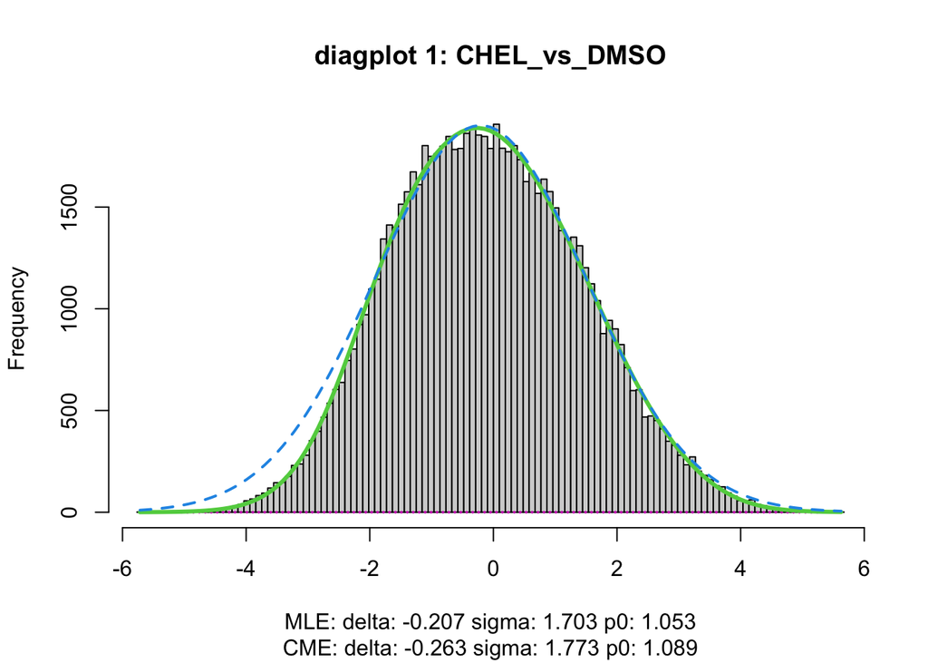

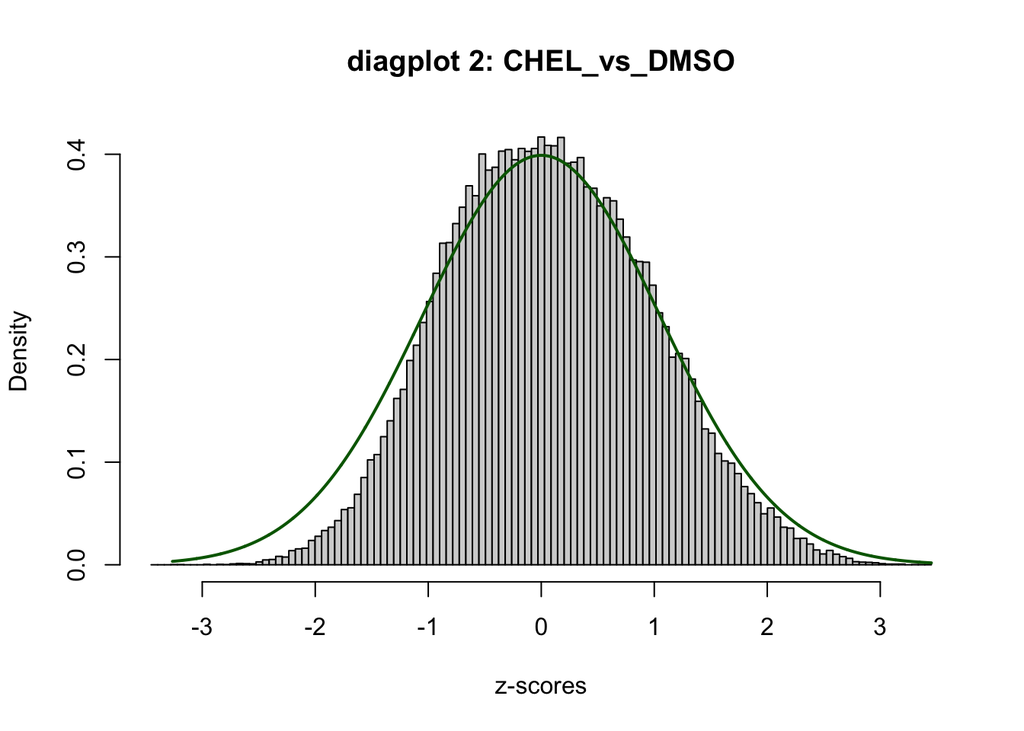

```r
se_chel <- satuRn::testDTU(
  object = se_chel,
  contrasts = L,
  diagplot1 = TRUE,
  diagplot2 = TRUE
)
```

```r
gene_ids <- rowData(se_chel)$gene_id

dtu_res_chel <- rowData(se_chel)[["fitDTUResult_CHEL_vs_DMSO"]] |>
  as.data.frame() |>
  tibble::rownames_to_column("tx_name") |>
  tibble::as_tibble() |>
  dplyr::mutate(gene_id = gene_ids) |>
  dplyr::select(tx_name, gene_id, estimates, pval, regular_FDR) |>
  dplyr::arrange(pval)

sig_res_chel <- dtu_res_chel |> dplyr::filter(regular_FDR < 0.1)

sig_res_chel <- sig_res_chel |> mutate(tx_id = tx_name)
sig_res_chel
```

```
## # A tibble: 6,727 × 6
##    tx_name            gene_id            estimates        pval regular_FDR tx_id
##    <chr>              <chr>                  <dbl>       <dbl>       <dbl> <chr>
##  1 ENST00000330883.9  ENSG00000055118.17     0.725     8.12e-9    0.000562 ENST…
##  2 ENST00000242351.10 ENSG00000105939.14    -1.29      1.40e-8    0.000562 ENST…
##  3 ENST00000337147.11 ENSG00000092820.19     1.41      2.22e-8    0.000592 ENST…
##  4 ENST00000367075.4  ENSG00000092820.19    -1.38      4.18e-8    0.000836 ENST…
##  5 ENST00000698295.1  ENSG00000072274.14    -2.02      5.22e-8    0.000837 ENST…
##  6 ENST00000292433.4  ENSG00000160888.7      0.800     1.38e-7    0.00161  ENST…
##  7 ENST00000351989.8  ENSG00000128191.17    -0.627     1.62e-7    0.00161  ENST…
##  8 ENST00000471652.1  ENSG00000105939.14     1.40      1.64e-7    0.00161  ENST…
##  9 ENST00000543796.6  ENSG00000132341.12    -0.622     1.84e-7    0.00161  ENST…
## 10 ENST00000588173.1  ENSG00000160888.7     -0.822     2.18e-7    0.00161  ENST…
## # ℹ 6,717 more rows
```

```r
# save for later use
saveRDS(dtu_res_chel, here("workflows/data/PCBP1/dtu_res_chel.rds"))
saveRDS(sig_res_chel, here("workflows/data/PCBP1/sig_res_chel.rds"))
```

```r
# load the saved DTU results
sig_res_chel <- readRDS(here("workflows/data/PCBP1/sig_res_chel.rds"))
sig_res_chel
```

```
## # A tibble: 6,727 × 6
##    tx_name            gene_id            estimates        pval regular_FDR tx_id
##    <chr>              <chr>                  <dbl>       <dbl>       <dbl> <chr>
##  1 ENST00000330883.9  ENSG00000055118.17     0.725     8.12e-9    0.000562 ENST…
##  2 ENST00000242351.10 ENSG00000105939.14    -1.29      1.40e-8    0.000562 ENST…
##  3 ENST00000337147.11 ENSG00000092820.19     1.41      2.22e-8    0.000592 ENST…
##  4 ENST00000367075.4  ENSG00000092820.19    -1.38      4.18e-8    0.000836 ENST…
##  5 ENST00000698295.1  ENSG00000072274.14    -2.02      5.22e-8    0.000837 ENST…
##  6 ENST00000292433.4  ENSG00000160888.7      0.800     1.38e-7    0.00161  ENST…
##  7 ENST00000351989.8  ENSG00000128191.17    -0.627     1.62e-7    0.00161  ENST…
##  8 ENST00000471652.1  ENSG00000105939.14     1.40      1.64e-7    0.00161  ENST…
##  9 ENST00000543796.6  ENSG00000132341.12    -0.622     1.84e-7    0.00161  ENST…
## 10 ENST00000588173.1  ENSG00000160888.7     -0.822     2.18e-7    0.00161  ENST…
## # ℹ 6,717 more rows
```

## Splice event detection with splicelogic for iron chelation

We run event detection on the iron chelation comparison (`sig_res_chel`). Both comparisons use the same FDR cut-off (`regular_FDR < 0.1`), so their event counts can be compared; chelation still has about ten times more significant transcripts than the knockdown.

### Direction of the events

CHEL (iron chelated) is the up side and DMSO (iron present) the reference. In the contrast `CHEL_vs_DMSO = conditionCHEL - conditionDMSO`, CHEL is the test group and DMSO the reference (the subtracted term), so the estimate is CHEL minus DMSO: positive when a transcript is used more after chelation, negative when it is used more in DMSO. Every event describes what chelated transcripts do compared with DMSO ones. As for the knockdown, the level order (`levels = c("DMSO", "CHEL")`) does not change the fit: the contrast alone sets the direction.

CHEL is the up side because PCBP1 is expected to act more in low iron, so in both comparisons the up side is the condition with more PCBP1 activity (WT for the knockdown, CHEL here). IE events then mean the same thing in both, exons whose inclusion PCBP1 promotes, which is why the analyses below focus on IE as in the knockdown section.

| Event | What happens | What it suggests about low iron |
| --- | --- | --- |
| IE | Exon is in chelated transcripts and absent from DMSO ones | Low iron promotes inclusion |

```r
# prepare exons for splicelogic
sig_exons_chel <- prepare_exons(
  txdb, sig_res_chel, coef_col = "estimates", verbose = TRUE
)
```

```
## Extracting exons from TxDb...
```

```
## Mapping transcript IDs...
```

```
## Merging DTU results onto exons...
```

```
## Done. Returned 59595 exon ranges from 6727 unique transcripts.
```

```r
#find ie
ie_events_chel <- sig_exons_chel |> preprocess(coef_col = "estimates") |> find_ie()

#find all events
events_chel <- sig_exons_chel |> preprocess(coef_col = "estimates") |> find_all_events()
```

```
## Calculating skipped exon events...
```

```
## Calculating included exon events...
```

```
## Calculating mutually exclusive exon events...
```

```
## Calculating retained intron events...
```

```
## Calculating spliced intron events...
```

```
## Calculating alternative 5' splice site events...
```

```
## Calculating alternative 3' splice site events...
```

```
## Calculating alternative transcription start site events...
```

```
## Calculating alternative transcription end site events...
```

```
## Done! 9461 events detected.
```

```r
# my_paste() is defined in the knockdown section
collapsed_events_chel <- events_chel |>
    dplyr::mutate(exon_key = paste(gene_id, seqnames, start, end, strand, sep = ":")) |>
    dplyr::group_by(exon_key, event_type) |>
    plyranges::reduce_ranges_directed(
        n = plyranges::n(),
        exon_id = my_paste(exon_id),
        tx_id = my_paste(tx_id),
        exon_rank = my_paste(exon_rank),
        event_tx_id = my_paste(event_tx_id),
  )
```

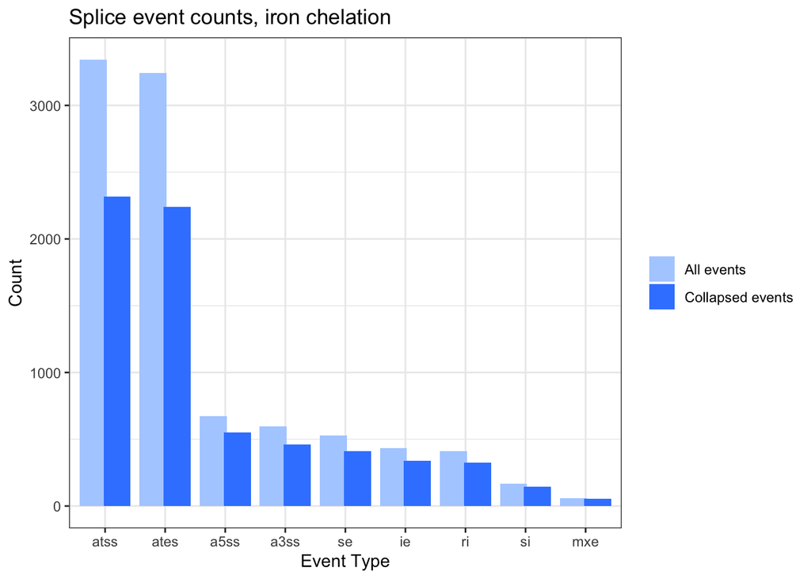

```r
event_counts_chel <- events_chel |>
    as_tibble() |>
    dplyr::group_by(event_type) |>
    dplyr::summarise(count = dplyr::n())

collapsed_event_counts_chel <- collapsed_events_chel |>
    as_tibble() |>
    dplyr::group_by(event_type) |>
    dplyr::summarise(count = dplyr::n())

# combine both count tables into one, labelled by source
counts_chel <- dplyr::bind_rows(
  "All events" = event_counts_chel,
  "Collapsed events" = collapsed_event_counts_chel,
  .id = "set"
)

# event types from most to fewest events
counts_chel$event_type <- factor(
  counts_chel$event_type,
  levels = event_counts_chel$event_type[order(-event_counts_chel$count)]
)

ggplot(counts_chel, aes(x = event_type, y = count, fill = set)) +
  geom_col(position = position_dodge(width = 0.8)) +
  scale_fill_manual(values = c(
    "All events" = "#B0CFFF",       # light blue
    "Collapsed events" = "#3A86FF"  # darker blue
  )) +
  labs(title = "Splice event counts, iron chelation",
  x = "Event Type", y = "Count", fill = NULL) +
  theme_bw()
```

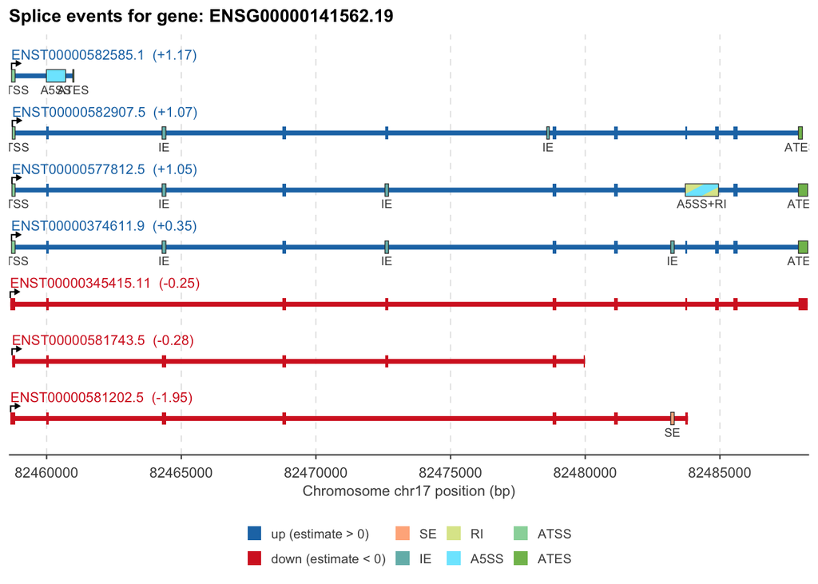

```r
# use splicelogic's built-in plotting function to visualize events for a specific gene:
# the one with the most IE events
gene_of_interest_chel <- names(sort(table(ie_events_chel$gene_id), decreasing = TRUE))[1]
# filter events for the gene of interest
events_for_gene_chel <- events_chel[events_chel$gene_id == gene_of_interest_chel]

# visualize the events for the gene of interest
splicelogic::plot_transcripts(events_for_gene_chel, sig_exons_chel, rescale_introns = FALSE) +
  ggtitle(paste("Splice events for gene:", gene_of_interest_chel))
```

```r
# make a plot for each gene with events and save to files
# plot_transcripts_by_gene returns a list of ggplot objects, one for each gene
plots_chel <- plot_transcripts_by_gene(events_chel, sig_exons_chel)
# save each plot to the same pdf file
pdf(here("workflows/figures/PCBP1_chel_splice_events_by_gene.pdf"), width = 8, height = 6)
for (gene in names(plots_chel)) {
    print(plots_chel[[gene]])
}
dev.off()
```

## Collapse redundant events

As for the knockdown: one row per exon for the sequence analyses below, with `n` the number of transcript pairs each exon came from, collapsing rows only for the same exon (gene, chromosome, start, end, strand) and event type. `collapse_exons_chel <- FALSE` runs the sequence analyses on every event instead.

```r
# TRUE: the sequence analyses below use one row per exon. FALSE: they use every
# IE event, one row per transcript pair, as before the collapse, to
# compare
collapse_exons_chel <- TRUE

ie_collapsed_chel <- ie_events_chel |>
    dplyr::mutate(exon_key = paste(gene_id, seqnames, start, end, strand, sep = ":")) |>
    dplyr::group_by(exon_key, event_type) |>
    plyranges::reduce_ranges_directed(
        n = plyranges::n(),
        gene_id = my_paste(gene_id),
        exon_id = my_paste(exon_id),
        tx_id = my_paste(tx_id),
        exon_rank = my_paste(exon_rank),
        event_tx_id = my_paste(event_tx_id),
  )

data.frame(
  events = length(ie_events_chel),
  exons  = length(ie_collapsed_chel),
  max_n  = max(ie_collapsed_chel$n)
)
```

```
##   events exons max_n
## 1    434   341     5
```

```r
# the set the sequence analyses below use
ie_exons_chel <- if (collapse_exons_chel) ie_collapsed_chel else ie_events_chel
```

### IE exons per gene

How the IE events spread across genes: the number of distinct IE exons in each gene. `ie_collapsed_chel` already has one row per exon and gene, with `n` the events it came from, so the counts come straight from it.

```r
ie_per_gene_chel <- ie_collapsed_chel |>
  dplyr::group_by(gene_id) |>
  dplyr::summarise(n_events = sum(n),
                   n_exons  = plyranges::n())

data.frame(
  ie_events = length(ie_events_chel),
  ie_exons  = length(ie_collapsed_chel),
  ie_genes  = nrow(ie_per_gene_chel)
)
```

```
##   ie_events ie_exons ie_genes
## 1       434      341      306
```

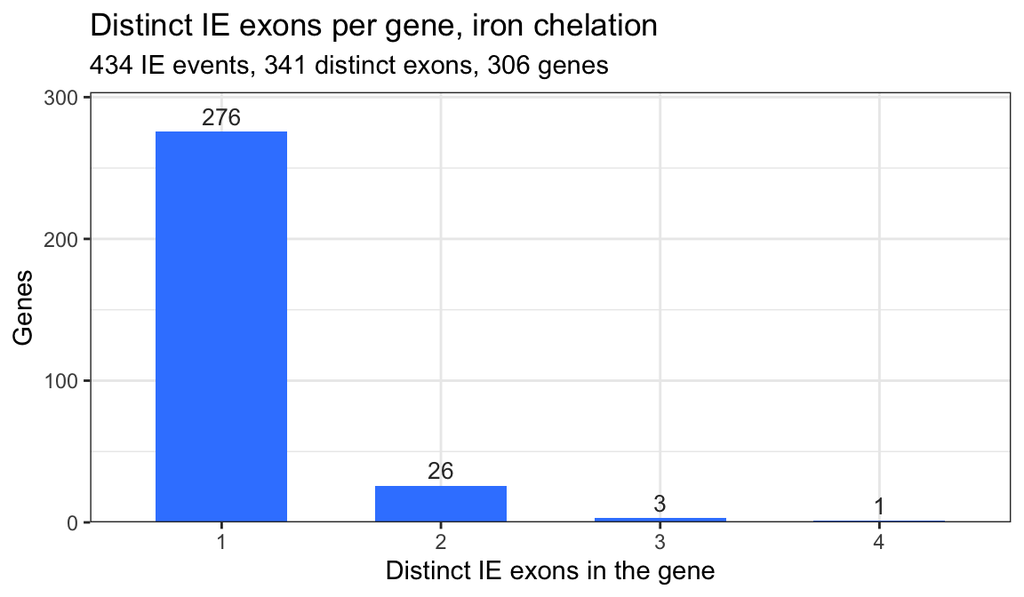

```r
# ggplot needs a data.frame, so the small per-gene summary is converted here
as.data.frame(ie_per_gene_chel) |>
  dplyr::count(n_exons) |>
  ggplot(aes(x = factor(n_exons), y = n)) +
  geom_col(fill = "#3A86FF", width = 0.6) +
  geom_text(aes(label = n), vjust = -0.4, size = 3.5, colour = "grey20") +
  scale_y_continuous(expand = expansion(mult = c(0, 0.1))) +
  labs(title = "Distinct IE exons per gene, iron chelation",
       subtitle = sprintf("%d IE events, %d distinct exons, %d genes",
                          length(ie_events_chel), length(ie_collapsed_chel),
                          nrow(ie_per_gene_chel)),
       x = "Distinct IE exons in the gene", y = "Genes") +
  theme_bw()
```

## Sequence context around the event exons, focusing on included exons (IE)

As for the knockdown, the analysis focuses on IE exons. The helpers from `helper.R` are already sourced above.

```r
ie_profiles_chel <- slEventFlankProfiles(ie_exons_chel, genome = "hg38", width = 100)

# rows = exons, cols = window_nucleotide (e.g. w1_A)
dim(ie_profiles_chel$upstream)
```

```
## [1] 341  76
```

```r
dim(ie_profiles_chel$downstream)
```

```
## [1] 341  76
```

### Background set

As for the knockdown: as many non-event exons as there are in `ie_exons_chel`, drawn from the internal exons of transcripts with no evidence of differential usage (`pval > 0.5`) in the chelation comparison.

```r
dtu_res_chel <- readRDS(here("workflows/data/PCBP1/dtu_res_chel.rds"))
non_event_chel <- slSampleNonEventExons(
  dtu_res_chel, exons, n = ie_exons_chel, pval_min = 0.5, seed = 1
)
non_event_chel
```

```
## GRanges object with 341 ranges and 5 metadata columns:
##         seqnames              ranges strand |   exon_id         exon_name
##            <Rle>           <IRanges>  <Rle> | <integer>       <character>
##     [1]    chr15   34258813-34258944      - |    566409 ENSE00003567507.1
##     [2]     chr6   38862280-38862458      + |    259628 ENSE00001734713.1
##     [3]     chr9   77339516-77339911      + |    363979 ENSE00000708158.1
##     [4]    chr12 122976871-122976970      + |    483580 ENSE00003683126.1
##     [5]     chr9 127454496-127454599      + |    368963 ENSE00003542435.1
##     ...      ...                 ...    ... .       ...               ...
##   [337]    chr16       686068-686186      - |    600685 ENSE00000873932.1
##   [338]    chr22   26476993-26477136      - |    764152 ENSE00003976036.1
##   [339]     chr2 135162748-135162851      + |     90581 ENSE00003689065.1
##   [340]    chr16   24930784-24931404      - |    607120 ENSE00003690660.1
##   [341]    chr12     6919566-6919763      + |    464797 ENSE00003892091.1
##         exon_rank             tx_id      pval
##         <integer>       <character> <numeric>
##     [1]         4 ENST00000561080.5  0.500555
##     [2]        43 ENST00000449981.6  0.502030
##     [3]        48 ENST00000360280.8  0.505354
##     [4]         4 ENST00000541360.5  0.506052
##     [5]         2 ENST00000485704.2  0.507115
##     ...       ...               ...       ...
##   [337]         8 ENST00000248142.7  0.984588
##   [338]         4 ENST00000699252.1  0.987013
##   [339]        22 ENST00000687199.1  0.987388
##   [340]        18 ENST00000303665.9  0.988134
##   [341]         8 ENST00000229277.6  0.992984
##   -------
##   seqinfo: 25 sequences (1 circular) from an unspecified genome; no seqlengths
```

```r
non_event_profiles_chel <- slEventFlankProfiles(
  non_event_chel, genome = "hg38", width = 100
)
dim(non_event_profiles_chel$upstream)
```

```
## [1] 341  76
```

The IE profiles stacked over the non-IE ones, on the same axes:

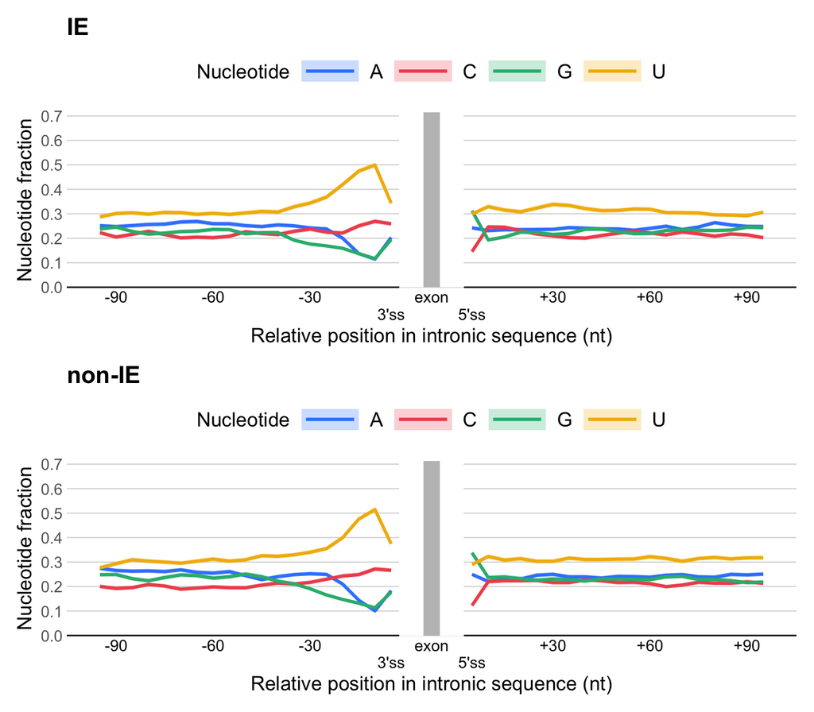

```r
patchwork::wrap_plots(
  slPlotFlankProfiles(ie_profiles_chel, exon_label = "IE"),
  slPlotFlankProfiles(non_event_profiles_chel, exon_label = "non-IE"),
  ncol = 1
)
```

The IE and non-IE sets, one panel per nucleotide (mean ± standard error), and next to them the difference between them, IE minus non-IE:

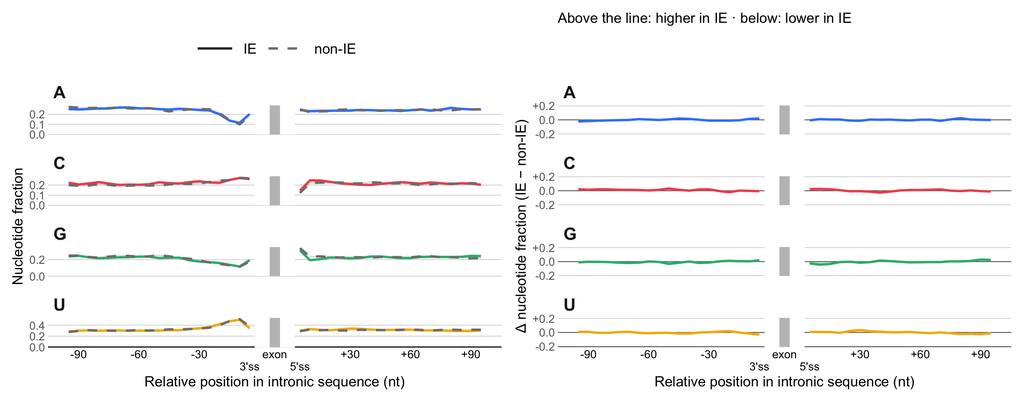

```r
ie_vs_non_event_chel <- list(IE = ie_profiles_chel, "non-IE" = non_event_profiles_chel)

patchwork::wrap_plots(
  slPlotFlankProfilesByNt(ie_vs_non_event_chel),
  slPlotFlankProfilesByNt(ie_vs_non_event_chel, difference = TRUE,
                          ylim = c(-0.2, 0.2)),
  nrow = 1
)
```

The within-transcript control, for each event the internal exon of the same transcript that is shared with the event partner and closest in rank to the event exon.

```r
matched_chel <- slMatchedNonEventExons(ie_events_chel, exons)

slEventFlankProfiles(matched_chel, genome = "hg38", width = 100) |>
  slPlotFlankProfiles(exon_label = "matched exon")
```

[output not shown]

## Splice-site sequence logos

Upstream holds the 3’ splice site and downstream the 5’ splice site, as explained in the knockdown section.

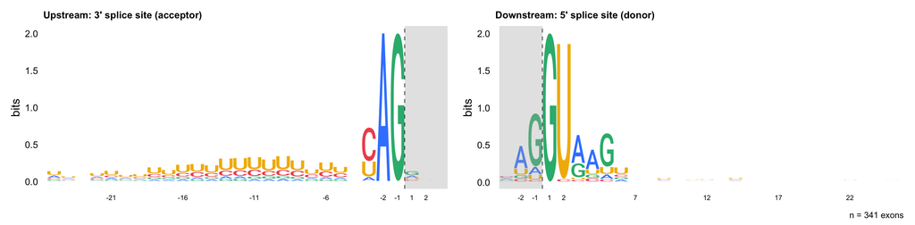

```r
ie_logo_chel <- slFlankLogoMatrices(ie_exons_chel, genome = "hg38",
                                    width = 25, exon_bases = 3)

# letter height = information content
slPlotFlankLogo(ie_logo_chel, method = "bits")
```

The same for the background set.

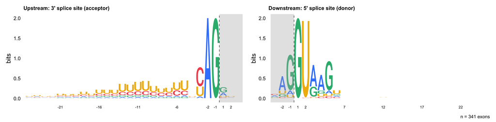

```r
non_event_logo_chel <- slFlankLogoMatrices(non_event_chel, genome = "hg38",
                                           width = 25, exon_bases = 3)

slPlotFlankLogo(non_event_logo_chel, method = "bits")
```

```r
# where the two sets differ most, per position and nucleotide
delta_up_chel <- ie_logo_chel$upstream - non_event_logo_chel$upstream
round(delta_up_chel[, order(-apply(abs(delta_up_chel), 2, max))[1:6]], 3)
```

```
##       -5     -4      2      1    -18    -25
## A  0.044  0.079 -0.009 -0.009 -0.067  0.021
## C  0.047  0.000 -0.041  0.041  0.000 -0.059
## G  0.047  0.018  0.079 -0.073  0.044 -0.026
## U -0.138 -0.097 -0.029  0.041  0.023  0.065
```

```r
delta_down_chel <- ie_logo_chel$downstream - non_event_logo_chel$downstream
round(delta_down_chel[, order(-apply(abs(delta_down_chel), 2, max))[1:6]], 3)
```

```
##        5     14     12     11      9     20
## A  0.009  0.035  0.006 -0.018 -0.012 -0.067
## C -0.003  0.032  0.067  0.000  0.070  0.053
## G -0.097 -0.094 -0.088 -0.059 -0.050  0.032
## U  0.091  0.026  0.015  0.076 -0.009 -0.018
```

## Genes with IE events

As for the knockdown, with every gene tested for DTU in the chelation comparison (`dtu_res_chel`) as the GO background. `strip_version()` and the CEGv2 list `ceg` come from the knockdown section.

```r
ie_genes_chel <- ie_events_chel |>
  as_tibble() |>
  dplyr::group_by(gene_id) |>
  dplyr::summarise(n_events = dplyr::n(),
                   n_exons  = dplyr::n_distinct(exon_id)) |>
  dplyr::mutate(
    ensembl = strip_version(gene_id),
    symbol  = AnnotationDbi::mapIds(org.Hs.eg.db, ensembl,
                                    "SYMBOL", "ENSEMBL"),
    entrez  = AnnotationDbi::mapIds(org.Hs.eg.db, ensembl,
                                    "ENTREZID", "ENSEMBL")
  )

universe_chel <- unique(strip_version(dtu_res_chel$gene_id))
```

```r
ie_genes_chel$essential <- ie_genes_chel$entrez %in% ceg$ENTREZ_ID

data.frame(
  ie_events        = length(ie_events_chel),
  ie_genes         = nrow(ie_genes_chel),
  with_symbol      = sum(!is.na(ie_genes_chel$symbol)),
  essential        = sum(ie_genes_chel$essential),
  genes_tested_dtu = length(universe_chel)
)
```

```
##   ie_events ie_genes with_symbol essential genes_tested_dtu
## 1       434      306         303        39            12113
```

```r
# the 20 IE genes with the most events (`ie_genes_chel` has them all)
ie_genes_chel |>
  dplyr::arrange(dplyr::desc(n_events), symbol) |>
  dplyr::select(symbol, gene_id, n_events, n_exons, essential) |>
  head(20)
```

```
## # A tibble: 20 × 5
##    symbol   gene_id            n_events n_exons essential
##    <chr>    <chr>                 <int>   <int> <lgl>
##  1 NARF     ENSG00000141562.19        8       6 FALSE
##  2 HNRNPA3  ENSG00000170144.22        5       3 FALSE
##  3 HNRNPD   ENSG00000138668.20        5       3 FALSE
##  4 SERPINB6 ENSG00000124570.21        5       1 FALSE
##  5 XPO1     ENSG00000082898.19        5       4 TRUE
##  6 AHI1     ENSG00000135541.22        4       2 FALSE
##  7 BAG6     ENSG00000204463.14        4       3 FALSE
##  8 MYB      ENSG00000118513.20        4       2 FALSE
##  9 NAP1L1   ENSG00000187109.15        4       3 FALSE
## 10 NASP     ENSG00000132780.17        4       2 FALSE
## 11 NDUFA5   ENSG00000128609.16        4       2 FALSE
## 12 PLEC     ENSG00000178209.17        4       1 FALSE
## 13 RAN      ENSG00000132341.12        4       2 TRUE
## 14 TBL1X    ENSG00000101849.18        4       1 FALSE
## 15 CAP1     ENSG00000131236.18        3       1 FALSE
## 16 CEP104   ENSG00000116198.14        3       3 FALSE
## 17 CYB5B    ENSG00000103018.18        3       1 FALSE
## 18 EIF4G1   ENSG00000114867.22        3       1 FALSE
## 19 ELOC     ENSG00000154582.18        3       1 FALSE
## 20 GNAS     ENSG00000087460.29        3       1 FALSE
```

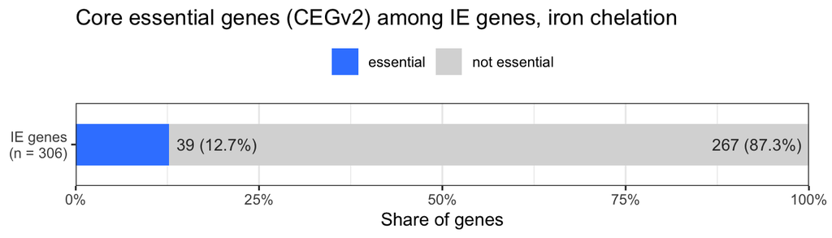

```r
# share of the IE genes that are core essential
ie_essential_df_chel <- data.frame(
  set    = sprintf("IE genes\n(n = %s)", scales::comma(nrow(ie_genes_chel))),
  status = factor(c("essential", "not essential"),
                  levels = c("essential", "not essential")),
  n      = c(sum(ie_genes_chel$essential), sum(!ie_genes_chel$essential))
) |>
  dplyr::mutate(frac  = n / sum(n),
                label = sprintf("%s (%.1f%%)", scales::comma(n), 100 * frac))

ggplot(ie_essential_df_chel, aes(x = frac, y = set, fill = status)) +
  geom_col(position = position_stack(reverse = TRUE), width = 0.6) +
  geom_text(data = \(d) dplyr::filter(d, status == "essential"),
            aes(label = label), hjust = 0, nudge_x = 0.01,
            size = 3.5, colour = "grey20") +
  geom_text(data = \(d) dplyr::filter(d, status == "not essential"),
            aes(x = 0.99, label = label), hjust = 1,
            size = 3.5, colour = "grey20") +
  scale_fill_manual(values = c("essential"     = "#3A86FF",
                               "not essential" = "grey85")) +
  scale_x_continuous(labels = scales::percent, expand = c(0, 0)) +
  labs(title = "Core essential genes (CEGv2) among IE genes, iron chelation",
       x = "Share of genes", y = NULL, fill = NULL) +
  theme_bw() +
  theme(legend.position = "top",
        plot.margin = margin(5.5, 14, 5.5, 5.5))
```

```r
# GO biological process; cutoffs at 1 so the top terms are always shown
ie_go_chel <- clusterProfiler::enrichGO(
  gene     = ie_genes_chel$ensembl,
  universe = universe_chel,
  OrgDb    = org.Hs.eg.db,
  keyType  = "ENSEMBL",
  ont      = "BP",
  pvalueCutoff = 1,
  qvalueCutoff = 1,
  readable = TRUE
)
as_tibble(ie_go_chel) |>
  dplyr::select(Description, GeneRatio, BgRatio, pvalue, p.adjust, geneID) |>
  head(10)
```

```
## # A tibble: 10 × 6
##    Description                         GeneRatio BgRatio  pvalue p.adjust geneID
##    <chr>                               <chr>     <chr>     <dbl>    <dbl> <chr>
##  1 regulation of mRNA splicing, via s… 14/282    95/9840 4.65e-7 0.000462 CLNS1…
##  2 RNA splicing, via transesterificat… 25/282    282/98… 4.93e-7 0.000462 CLNS1…
##  3 mRNA splicing, via spliceosome      25/282    282/98… 4.93e-7 0.000462 CLNS1…
##  4 RNA splicing, via transesterificat… 25/282    286/98… 6.42e-7 0.000462 CLNS1…
##  5 regulation of mRNA processing       15/282    117/98… 1.14e-6 0.000655 CLNS1…
##  6 RNA splicing                        30/282    402/98… 1.40e-6 0.000671 CLNS1…
##  7 regulation of RNA splicing          17/282    157/98… 2.43e-6 0.000997 CLNS1…
##  8 mRNA processing                     30/282    427/98… 4.80e-6 0.00173  PRKAC…
##  9 ribosomal subunit export from nucl… 5/282     12/9840 1.25e-5 0.00360  RIOK2…
## 10 ribosome localization               5/282     12/9840 1.25e-5 0.00360  RIOK2…
```

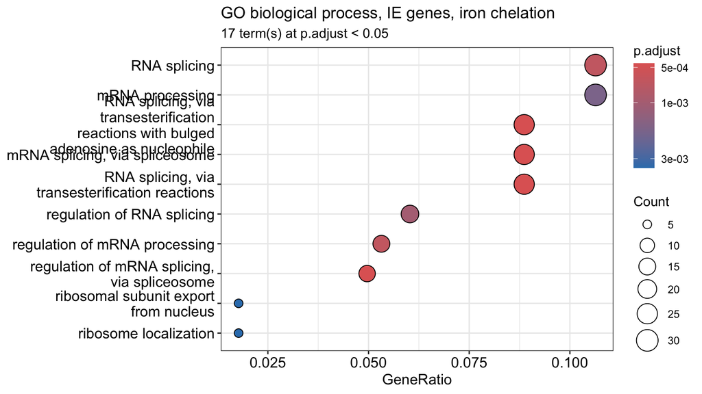

```r
enrichplot::dotplot(ie_go_chel, showCategory = 10) +
  labs(title = "GO biological process, IE genes, iron chelation",
       subtitle = sprintf("%d term(s) at p.adjust < 0.05",
                          sum(ie_go_chel@result$p.adjust < 0.05)))
```

# Knockdown vs chelation

## IE events in both comparisons

In both comparisons the up side is the condition with more PCBP1 activity (WT for the knockdown, CHEL for the chelation), so an IE event means the same thing in both: an exon whose inclusion goes with more PCBP1 activity. If chelation acts through PCBP1, the IE events of the two comparisons should overlap.

The overlap is counted at three levels: genes, transcripts (only those that include the IE exon, `tx_id`, not the partner transcripts that skip it) and exons (`exon_key`, the gene and exact position, from the collapsed sets). Both comparisons use the same annotation (GENCODE v43), so the identifiers match. Chelation has many more IE events than the knockdown, so the telling number is the share of the knockdown set that is also found after chelation (`kd_in_chel`).

```r
ie_sets <- list(
  genes = list(
    kd   = unique(ie_events$gene_id),
    chel = unique(ie_events_chel$gene_id)
  ),
  transcripts = list(
    kd   = unique(ie_events$tx_id),
    chel = unique(ie_events_chel$tx_id)
  ),
  exons = list(
    kd   = unique(ie_collapsed$exon_key),
    chel = unique(ie_collapsed_chel$exon_key)
  )
)

ie_overlap <- do.call(rbind, lapply(names(ie_sets), function(level) {
  kd     <- ie_sets[[level]]$kd
  chel   <- ie_sets[[level]]$chel
  shared <- intersect(kd, chel)
  data.frame(
    level      = level,
    knockdown  = length(kd),
    chelation  = length(chel),
    shared     = length(shared),
    kd_in_chel = round(length(shared) / length(kd), 3),
    chel_in_kd = round(length(shared) / length(chel), 3),
    jaccard    = round(length(shared) / length(union(kd, chel)), 3)
  )
}))
ie_overlap
```

```
##         level knockdown chelation shared kd_in_chel chel_in_kd jaccard
## 1       genes        50       306      3      0.060      0.010   0.008
## 2 transcripts        52       351      2      0.038      0.006   0.005
## 3       exons        57       341      2      0.035      0.006   0.005
```

UpSet plots for genes and transcripts: the bars on top are the knockdown-only, shared and chelation-only sets, the dots below show which comparison each bar belongs to, and the bars on the left are the size of each IE set. The shared set is highlighted.

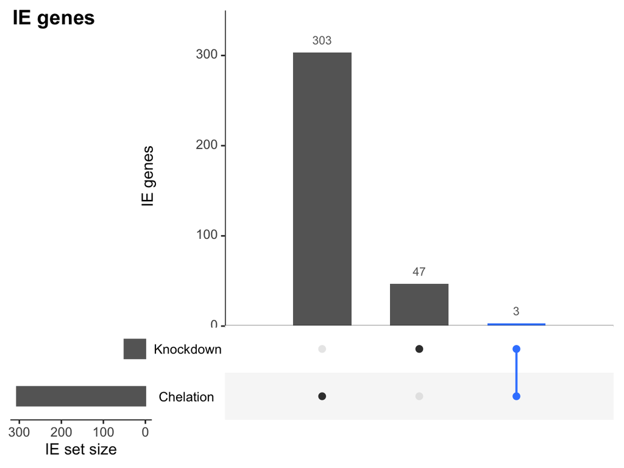

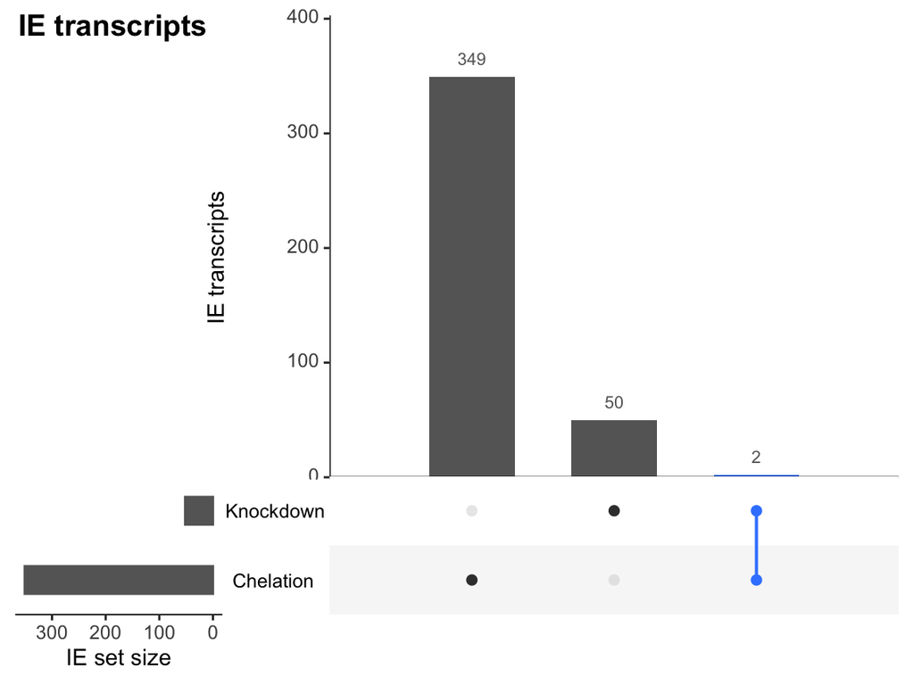

```r
# one UpSet plot per level; out.width = 50% puts the two side by side
for (level in c("genes", "transcripts")) {
  print(UpSetR::upset(
    UpSetR::fromList(list(Knockdown = ie_sets[[level]]$kd,
                          Chelation = ie_sets[[level]]$chel)),
    sets            = c("Chelation", "Knockdown"),
    keep.order      = TRUE,
    order.by        = "freq",
    main.bar.color  = "grey40",
    sets.bar.color  = "grey40",
    queries         = list(list(query  = UpSetR::intersects,
                                params = list("Knockdown", "Chelation"),
                                color  = "#3A86FF", active = TRUE)),
    mainbar.y.label = paste("IE", level),
    sets.x.label    = "IE set size",
    text.scale      = 1.3
  ))
  grid::grid.text(paste("IE", level), x = 0.02, y = 0.98,
                  just = c("left", "top"),
                  gp = grid::gpar(fontsize = 14, fontface = "bold"))
}
```

The genes and transcripts with IE events in both comparisons: the shared genes with their full name and number of IE events in each comparison, and the transcripts that include an IE exon in both.

```r
shared_genes <- intersect(ie_sets$genes$kd, ie_sets$genes$chel)

ie_genes |>
  dplyr::filter(gene_id %in% shared_genes) |>
  dplyr::select(symbol, gene_id, n_events_kd = n_events) |>
  dplyr::left_join(
    dplyr::select(ie_genes_chel, gene_id, n_events_chel = n_events),
    by = "gene_id"
  ) |>
  dplyr::mutate(
    name = AnnotationDbi::mapIds(org.Hs.eg.db, strip_version(gene_id),
                                 "GENENAME", "ENSEMBL"),
    .after = gene_id
  ) |>
  dplyr::arrange(symbol) |>
  knitr::kable()
```

| symbol | gene_id | name | n_events_kd | n_events_chel |
| --- | --- | --- | --- | --- |
| ERCC1 | ENSG00000012061.16 | ERCC excision repair 1, endonuclease non-catalytic subunit | 1 | 1 |
| FAAP20 | ENSG00000162585.17 | FA core complex associated protein 20 | 1 | 1 |
| GUK1 | ENSG00000143774.18 | guanylate kinase 1 | 2 | 1 |

```r
tibble::tibble(
  tx_id = intersect(ie_sets$transcripts$kd, ie_sets$transcripts$chel)
) |>
  dplyr::left_join(
    dplyr::distinct(tibble::tibble(tx_id   = ie_events$tx_id,
                                   gene_id = ie_events$gene_id)),
    by = "tx_id"
  ) |>
  dplyr::left_join(dplyr::select(ie_genes, gene_id, symbol), by = "gene_id") |>
  dplyr::select(symbol, gene_id, tx_id) |>
  dplyr::arrange(symbol, tx_id) |>
  knitr::kable()
```

| symbol | gene_id | tx_id |
| --- | --- | --- |
| ERCC1 | ENSG00000012061.16 | ENST00000013807.9 |
| FAAP20 | ENSG00000162585.17 | ENST00000378546.9 |

GO annotation of the shared genes, from org.Hs.eg.db with the term names from GO.db: one row per gene and ontology (BP biological process, MF molecular function, CC cellular component).

```r
shared_go <- AnnotationDbi::select(
  org.Hs.eg.db, keys = strip_version(shared_genes),
  columns = c("SYMBOL", "GO", "ONTOLOGY"), keytype = "ENSEMBL"
) |>
  dplyr::filter(!is.na(GO)) |>
  dplyr::distinct(SYMBOL, GO, ONTOLOGY)

go_terms <- AnnotationDbi::mapIds(GO.db::GO.db, unique(shared_go$GO),
                                  "TERM", "GOID")
shared_go$term <- go_terms[shared_go$GO]

shared_go |>
  dplyr::mutate(ONTOLOGY = factor(ONTOLOGY, levels = c("BP", "MF", "CC"))) |>
  dplyr::group_by(symbol = SYMBOL, ontology = ONTOLOGY) |>
  dplyr::summarise(n_terms = dplyr::n_distinct(term),
                   terms   = paste(sort(unique(term)), collapse = "; "),
                   .groups = "drop") |>
  dplyr::arrange(symbol, ontology) |>
  knitr::kable()
```

| symbol | ontology | n_terms | terms |
| --- | --- | --- | --- |
| ERCC1 | BP | 16 | DNA damage response; DNA recombination; DNA repair; double-strand break repair; double-strand break repair via nonhomologous end joining; mitotic recombination; negative regulation of protection from … |
| ERCC1 | MF | 8 | 3’ overhang single-stranded DNA endodeoxyribonuclease activity; damaged DNA binding; DNA binding; promoter-specific chromatin binding; protein binding; single-stranded DNA binding; single-stranded DNA… |
| ERCC1 | CC | 7 | chromosome, telomeric region; cytoplasm; ERCC4-ERCC1 complex; nucleoplasm; nucleotide-excision repair complex; nucleotide-excision repair factor 1 complex; nucleus |
| FAAP20 | BP | 4 | DNA damage response; DNA repair; interstrand cross-link repair; translesion synthesis |
| FAAP20 | MF | 7 | K63-linked polyubiquitin modification-dependent protein binding; metal ion binding; polyubiquitin modification-dependent protein binding; protein binding; ubiquitin binding; ubiquitin-modified protein… |
| FAAP20 | CC | 7 | chromatin; chromosome; cytosol; Fanconi anaemia nuclear complex; nuclear body; nucleoplasm; nucleus |
| GUK1 | BP | 10 | dATP metabolic process; dGDP biosynthetic process; dGMP metabolic process; GDP biosynthetic process; GDP-mannose metabolic process; glycoprotein transport; GMP metabolic process; nucleobase-containing… |
| GUK1 | MF | 6 | ATP binding; GMP kinase activity; kinase activity; nucleotide binding; protein binding; transferase activity |
| GUK1 | CC | 3 | cytosol; mitochondrion; photoreceptor inner segment |